# Bayesian Survival Analysis of Customer Churn

## 7. Predictive Analysis

### 7.1 Posterior Predictions for New Customers

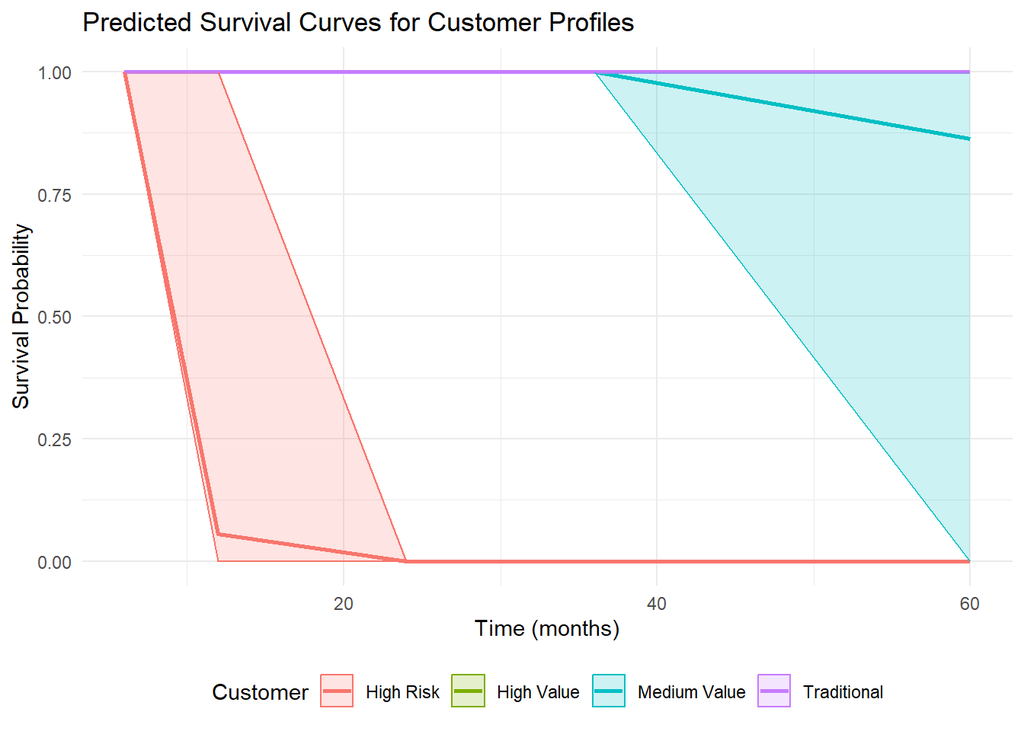

```r
# Create new customers
new_customers <- data.frame(
  Partner = c("Yes", "No", "Yes", "No"),
  InternetService = c("Fiber optic", "DSL", "Fiber optic", "No"),
  OnlineSecurity = c("Yes", "No", "No", "No internet service"),
  DeviceProtection = c("Yes", "No", "Yes", "No internet service"),
  StreamingTV = c("Yes", "No", "Yes", "No internet service"),
  StreamingMovies = c("Yes", "No", "No", "No internet service"),
  Contract = c("Two year", "Month-to-month", "One year", "Month-to-month"),
  PaperlessBilling = c("Yes", "Yes", "No", "No"),
  PaymentMethod = c("Bank transfer (automatic)", "Electronic check",
                   "Credit card (automatic)", "Mailed check"),
  TotalCharges_scaled = c(1, -1, 0, -0.5),
  Customer_Type = c("High Value", "High Risk", "Medium Value", "Traditional")
)

# Generate predictions
pred_draws <- posterior_epred(bayes_weibull,
                             newdata = new_customers,
                             ndraws = 4000)

# Calculate survival probabilities at different time points
time_points <- c(6, 12, 24, 36, 60)
survival_probs <- list()

for (i in 1:nrow(new_customers)) {
  customer_draws <- pred_draws[, i]
  probs <- sapply(time_points, function(t) mean(customer_draws > t))
  survival_probs[[i]] <- data.frame(
    Customer = new_customers$Customer_Type[i],
    Time = time_points,
    Survival_Prob = probs,
    Lower_CI = sapply(time_points, function(t) quantile(customer_draws > t, 0.025)),
    Upper_CI = sapply(time_points, function(t) quantile(customer_draws > t, 0.975))
  )
}

# Plot
all_survival_probs <- bind_rows(survival_probs)

ggplot(all_survival_probs, aes(x = Time, y = Survival_Prob, color = Customer)) +
  geom_line(linewidth = 1) +
  geom_ribbon(aes(ymin = Lower_CI, ymax = Upper_CI, fill = Customer), alpha = 0.2) +
  scale_y_continuous(limits = c(0, 1)) +
  labs(title = "Predicted Survival Curves for Customer Profiles",
       x = "Time (months)", y = "Survival Probability") +
  theme(legend.position = "bottom")
```

```r
# Median survival times
median_survival <- data.frame(
  Customer_Type = new_customers$Customer_Type,
  Median_Survival = apply(pred_draws, 2, median),
  Q25 = apply(pred_draws, 2, quantile, 0.25),
  Q75 = apply(pred_draws, 2, quantile, 0.75)
)

median_survival %>%
  gt() %>%
  tab_header(title = "Predicted Median Survival Times") %>%
  fmt_number(columns = -Customer_Type, decimals = 1)
```

Predicted Median Survival Times

| Customer_Type | Median_Survival | Q25 | Q75 |
| --- | --- | --- | --- |
| High Value | 1,181.9 | 1,047.5 | 1,343.9 |
| High Risk | 11.1 | 10.7 | 11.5 |
| Medium Value | 66.1 | 62.3 | 70.5 |
| Traditional | 78.8 | 74.3 | 83.7 |

Here we created different customer profiles and used our model to predict survival curves for each. The plot illustrates that a high risk customer (month-to-month contract) has a survival probability that quickly decreases to zero, while a medium value customer (one year contract) starts to slowly decrease at around 35 months. The table of median survival times shows that a high value customer (two year contract) has a median survival time of 98 years. Although we expect this type of customer to have a longer survival time, this quantity is much larger than any observed survival time in the data (the maximum being 72 months (6 years)), so we are hesitant to trust these results.

## 8. Model Comparison Using Information Criteria

```r
# Calculate WAIC and LOO
waic_result <- waic(bayes_weibull)
loo_result <- loo(bayes_weibull)

waic_result_inform <- waic(bayes_weibull_inform)
loo_result_inform <- loo(bayes_weibull_inform)

waic_result_vague <- waic(bayes_weibull_vague)
loo_result_vague <- loo(bayes_weibull_vague)

cat("Default\n")
```

```
Default
```

```r
cat("WAIC: ", waic_result$estimates["waic", "Estimate"],
    " (SE: ", waic_result$estimates["waic", "SE"], ")\n", sep = "")
```

```
WAIC: 15702.76 (SE: 293.2267)
```

```r
cat("LOO: ", loo_result$estimates["looic", "Estimate"],
    " (SE: ", loo_result$estimates["looic", "SE"], ")\n", sep = "")
```

```
LOO: 15702.78 (SE: 293.227)
```

```r
cat("\nInformative\n")
```

```
Informative
```

```r
cat("WAIC: ", waic_result_inform$estimates["waic", "Estimate"],
    " (SE: ", waic_result_inform$estimates["waic", "SE"], ")\n", sep = "")
```

```
WAIC: 15704.69 (SE: 292.2495)
```

```r
cat("LOO: ", loo_result_inform$estimates["looic", "Estimate"],
    " (SE: ", loo_result_inform$estimates["looic", "SE"], ")\n", sep = "")
```

```
LOO: 15704.71 (SE: 292.2499)
```

```r
cat("\nVague\n")
```

```
Vague
```

```r
cat("WAIC: ", waic_result_vague$estimates["waic", "Estimate"],
    " (SE: ", waic_result_vague$estimates["waic", "SE"], ")\n", sep = "")
```

```
WAIC: 15703.04 (SE: 293.6181)
```

```r
cat("LOO: ", loo_result_vague$estimates["looic", "Estimate"],
    " (SE: ", loo_result_vague$estimates["looic", "SE"], ")\n", sep = "")
```

```
LOO: 15703.06 (SE: 293.6184)
```

We decided to use standardized metrics to test our model’s predictive ability. The widely applicable information criterion (WAIC) and leave-one-out cross-validation (LOO) values can be used to compare models, with smaller values indicating a better model. Using the same priors as before, we can see that the best model is made using our initially selected prior (default) for both metrics (although it is very close).

## 9. Conclusions

### 9.2 Advantages of the Bayesian Approach

1. **Full Uncertainty Quantification**: Unlike point estimates with confidence intervals, this model provides posterior distributions for all parameters.
2. **Probabilistic Statements**: We can make direct probability statements (e.g., “There’s a 99.9% probability that two-year contracts reduce churn”) rather than confidence statements.
3. **Predictive Distributions**: Natural framework for generating predictions with uncertainty for new customers.
4. **Model Flexibility**: The Weibull assumption is more flexible than the Cox model’s proportional hazards assumption, which was violated for most variables in the frequentist analysis.
5. **Prior Information**: Ability to incorporate domain knowledge through priors (though our analysis used weakly informative priors).

### 9.3 Comparison with Frequentist Results

The main differences are:

- The Bayesian approach doesn’t suffer from proportional hazards violations
- We get full posterior distributions rather than point estimates